# 7_Factors_Dates_Times

BM

24/11/2021

# Workshop 7: Factors, Dates and Times

This workshop covers chapters 15 and 16 of R4DS (online version.)

In R factors work with categorical variables, that is variables with a known set of possible values. They can also be used to display character vectors in non-alphabetical order.

The cheat sheet for factors is called forcats (anagram of factors)

# Factors

## Creating factors

```r
x1 <- c("Dec", "Apr", "Jan", "Mar")
x2 <- c("Dec", "Apr", "Jam", "Mar")
sort(x1)

month_levels <- c(
  "Jan", "Feb", "Mar", "Apr", "May", "Jun",
  "Jul", "Aug", "Sep", "Oct", "Nov", "Dec"
)

y1 <- factor(x1, levels = month_levels)

sort(y1)

y2 <- factor(x2, levels = month_levels)
y2
```

[output not shown]

The levels sets out the order of the factor, without them they will be delivered alphabetically. In the above example the Jam not in the levels was silently converted to an NA. You can check via

```r
y2 <- parse_factor(x2, levels = month_levels)
```

```r
f1 <- factor(x1, levels = unique(x1))
f1


f2 <- x1 %>% factor() %>% fct_inorder()
f2
```

[output not shown]

You can find the levels in data with

```r
levels(f2)
```

```
## [1] "Dec" "Apr" "Jan" "Mar"
```

## GSS (General Social Survery)

```r
gss_cat %>%
  count(race)
```

```
## # A tibble: 3 x 2
##   race      n
##   <fct> <int>
## 1 Other  1959
## 2 Black  3129
## 3 White 16395
```

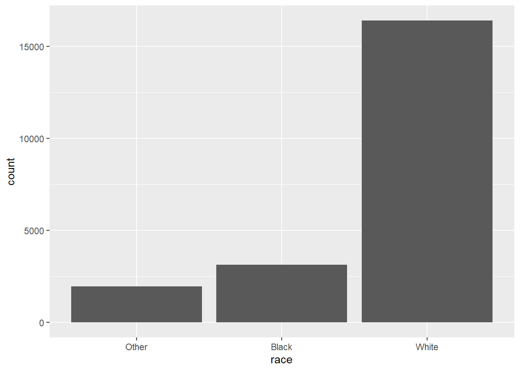

```r
ggplot(gss_cat, aes(x = race)) +
  geom_bar()
```

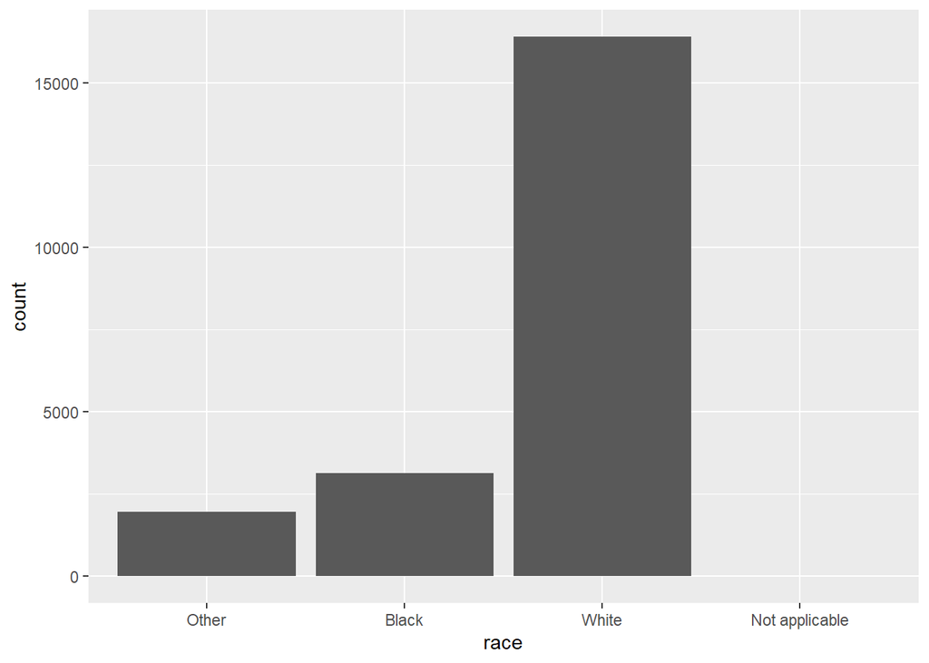

```r
ggplot(gss_cat, aes(x = race)) +
  geom_bar() +
  scale_x_discrete(drop = FALSE)
```